# Distance metrics and clustering

### Pearson’s correlation coefficient

The Pearson’s correlation coefficient is a widely used statistical score to measure the co-variance of two variables. It is particularly used in the case of hierarchical clustering applied to microarray or RNA-Seq data. The Pearson’s correlation coefficient can be computed by dividing the covariance of the two variables by the product of their standard deviations.

$$r_{x,y}= \frac{1}{n}\sum\limits_{i=1}^n \frac{(x_i - \bar{x})(y_i - \bar{y})}{s_xs_y} = \frac{cov(x,y)}{s_xs_y}$$

Let’s go back to the example we provided above. We had three objects ($a$, $b$ and $c$) having values associated with a set of variables. These object could be viewed as a small set of genes having given expression values in a set of biological samples. We will construct a new diagram in which we will display for each gene (a, b, and c) through each sample (8 dimensions) the difference to the corresponding mean value ($x_i - \bar{x}$). The covariance is the sum of the products of the differences through the eight dimensions. If for in dimension the intensities of two gene goes jointly above their corresponding mean, this product will be positive. In the same way, if their intensities goes jointly above their corresponding mean, this product will be positive. It will be negative or zero in the other cases. The fact that the covariance is divided by the product of the standard deviation will ensure that the Pearson’s $r$ coefficient is bound between -1 (the more negative corresponding to anti-correlation) and 1 (complete correlation).

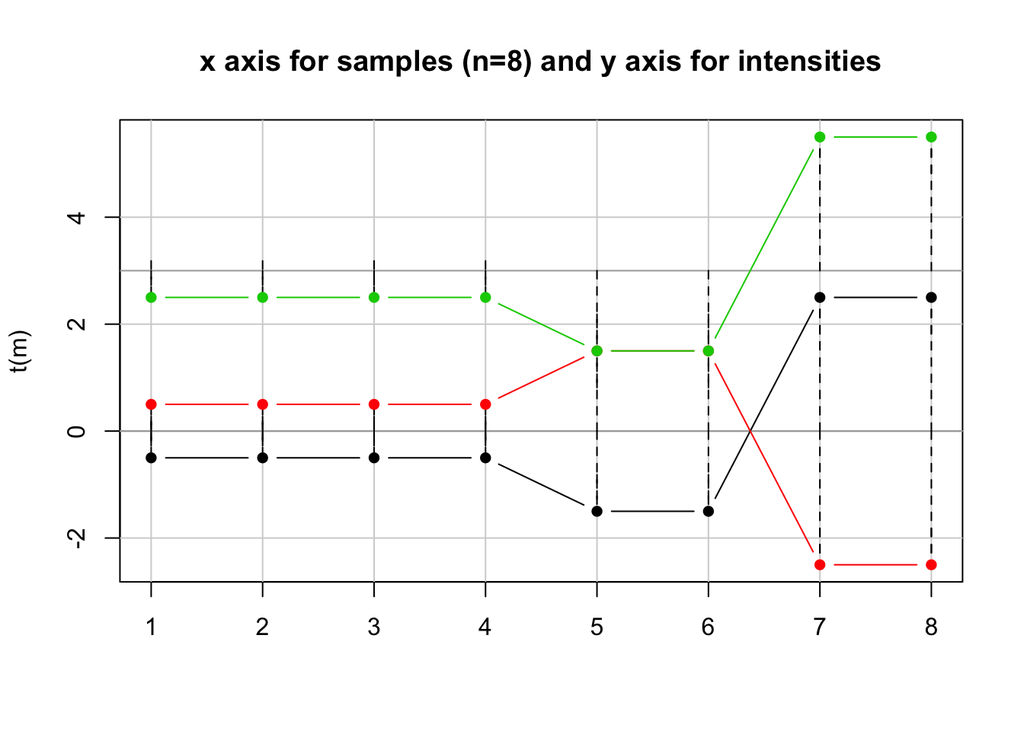

```r
col.vec <- c(col.vec, "green")
# The dataset
a <- c(7, 7, 7, 7, 6, 6, 10, 10)
a <- a - mean(a)
b <- -a + mean(a)
c <- a + 3
m <- rbind(a,b,c)

# The mean intensities
a.mean <- mean(a)
b.mean <- mean(b)
c.mean <- mean(c)

# The diagram with the three genes: a, b, c
matplot(t(m),
       main="x axis for samples (n=8) and y axis for intensities",
        pch=16,
        col="black",
        lty=1,
        type="n")
grid(lty=1)

mean.all <- c(a.mean, b.mean, c.mean)
abline(h=mean.all, lty=1, col="darkgrey")

gene.list <- list(a,b,c)

# The differences to the means
for(g in 1:length(gene.list)){
  for(i in 1:length(a)){
    arrows(i, mean.all[g] , i, gene.list[[g]][i], angle=0, lty=2)
  }
}

matpoints(t(m),
        pch=16,
        type="b",
        lty=1)
```

**Exercise:**

> - Compute the Pearson’s correlation coefficient between $a$ and $c$ using the formula.
> - Is that results expected.
> - Compute it using the cor() function. Is the same result obtained ?
> - What is the result obtained when comparing $a$ and $b$ ?
> - Is this metric a good choice for comparing two gene expression profile ?

<< Hide | Show >>

```r
n <- 8
# Compute sample standard deviation
sd.a <- sqrt(1/n * sum((a-a.mean)^2))
sd.c <- sqrt(1/n * sum((c-c.mean)^2))

# Compute Co-variance
cov.a.c <- 1/n*sum((a-a.mean) * (c-c.mean))
cor.a.c <- cov.a.c/(sd.a*sd.c)
cor.a.c
```

```
## [1] 1
```

```r
all.equal(cor.a.c, cor(a,c))
```

```
## [1] TRUE
```

```r
# Correlation between a and b.
# a and b are anti-correlated
cor(a,b)
```

```
## [1] -1
```

This correlation coefficient can be simply transformed into a distance using the following formula:

$$d(x,y) = 1/2(1-r_{x,y})$$

For any gene pair with a Pearson’s correlation coefficient of 1 the corresponding distance will be 0 while those displaying value of -1 will have an associated distance of 1. It should be noted that in contrast to euclidean distance, this distance does not follow the rule of triangle inequality that states that for any triangle the sum of the length of two given sides must be greater than the length of the third side. This type of distance can thus not be used to represent gene distances in a euclidean space.

### Spearman’s correlation coefficient $\rho$

Spearman’s correlation coefficient can be also particularly useful to assess the similarity of two given expression profile. While this rank-based measure is more robust to outliers than Pearson’s correlation coefficient, it is also less sensitive. While Pearson’s correlation coefficient is constructed based on raw values, Spearman’s correlation coefficient will assess the concordance between the ranks of these values. The formula of the Speaman ’s correlation coefficient is provided below. In this formula $d$ is the difference between ranks.

$$\rho = {1- \frac {6 \sum d_i^2}{n(n^2 - 1)}}$$

As for the Pearson’s correlation coefficient, $\rho$ can be transformed to a distance using:

$$d(x,y) = 1/2(1-\rho_{x,y})$$

### Comparing Spearman and Pearson correlation coefficient results

Also lot of other metric exist, Spearman and Pearson correlation coefficient (or their associated distance) are frequently a good choice when working with expression data. However, depending on the context, it is advisable to use the appropriate coefficient since their results may greatly differ. One can keep in mind that Pearson will capture linear relationships while Spearman will capture monotonic relationships. Let’s take some example and compute the results of both coefficient.

```r
op <- par(no.readonly = TRUE)
par(mfrow = c(2, 2), mar = c(3, 4, 0, 0.2)) #it goes c(bottom, left, top, right)
## An example where the result of both approaches are consistant
set.seed(1)
a <- rnorm(20)
b <- a + rnorm(20,sd=0.1)
plot(a,b, pch=16, las=1, panel.first=grid(lty=1))
cor.a.b.pear <- paste("r=", round(cor(a,b), 3))
cor.a.b.spear <- round(cor(a,b, method="spearman"), 3)
cor.a.b.spear <- paste("\u03C1=", cor.a.b.spear, sep="")
legend("topleft", leg=c(cor.a.b.spear,
                           cor.a.b.pear ))

## Another example where the result of both approaches are consistant
set.seed(1)
a <- rnorm(20)
b <- -a + rnorm(20,sd=0.1)
plot(a,b, pch=16, las=1, panel.first=grid(lty=1))
cor.a.b.pear <- paste("r=", round(cor(a,b), 3))
cor.a.b.spear <- round(cor(a,b, method="spearman"), 3)
cor.a.b.spear <- paste("\u03C1=", cor.a.b.spear, sep="")
legend("topright", leg=c(cor.a.b.spear,
                           cor.a.b.pear ))

## An example with non linear relationship
a <- 1:50
b <- exp(a)
plot(a,b, pch=16, las=1, panel.first=grid(lty=1))
cor.a.b.pear <- paste("r=", round(cor(a,b), 3))
cor.a.b.spear <- round(cor(a,b, method="spearman"), 3)
cor.a.b.spear <- paste("\u03C1=", cor.a.b.spear, sep="")
legend("topleft", leg=c(cor.a.b.spear,
                           cor.a.b.pear ))

## An example with an outlier.
## Rank concordance is observed only in one dimension
set.seed(1)
a <- rnorm(10)
b <- rnorm(10)
rank(a) - rank(b)
```

```
##  [1] -7  0 -1  9 -3 -1  3  1  1 -2
```

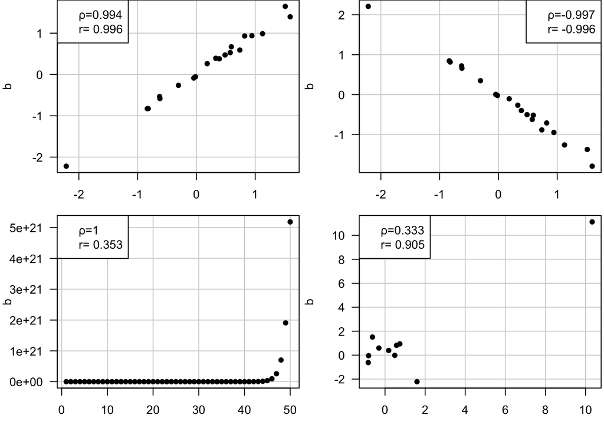

```r
a[5] <- a[5] + 10
b[5] <- b[5] + 10
plot(a,b, pch=16, las=1, panel.first=grid(lty=1))
cor.a.b.pear <- paste("r=", round(cor(a,b), 3))
cor.a.b.spear <- round(cor(a,b, method="spearman"), 3)
cor.a.b.spear <- paste("\u03C1=", cor.a.b.spear, sep="")
legend("topleft", leg=c(cor.a.b.spear,
                           cor.a.b.pear ))
```